# non_kep_eccentricity

```python
%%bash

export LD_LIBRARY_PATH=$LD_LIBRARY_PATH:/home/aleksey/rebound
```

```python
from IPython.display import HTML

HTML('''<script>
code_show=true;
function code_toggle() {
 if (code_show){
 $('div.input').hide();
 } else {
 $('div.input').show();
 }
 code_show = !code_show
}
$( document ).ready(code_toggle);
</script>
<form action="javascript:code_toggle()"><input type="submit" value="Click here to toggle on/off the raw code."></form>''')
```

The total potential including stars and the central black hole

$\Phi(r)=-\frac{G M_{bh}}{r}-\frac{G M_*(r)}{r}-4 \pi G \int_{r}^{\infty} \rho_\star(r') r' dr'$, (1)

where $M_*$ and $\rho_*$ correspond to the stellar mass and density. Note that

$\frac{-d \Phi}{dr}=-\frac{G (M_{bh}+M_*(r))}{r^2}.$

We will consider a broken power law for the density profile:

$\rho_*(r)=\rho_*(r_b) \left(\frac{r}{r_b}\right)^{\alpha-3}$, if $r \leq r_b$

and

$\rho_*(r)=\rho_*(r_b) \left(\frac{r}{r_b}\right)^{\beta-3}$, if $r > r_b$

The corresponding stellar mass profile is

$M_*(r)=M_*(r_b) \left(\frac{r}{r_b}\right)^{\alpha}$, if $r \leq r_b$

and

$M_*(r)=M_*(r_b)+\frac{\alpha}{\beta} M_*(r_b) \left[\left(\frac{r}{r_b}\right)^\beta-1\right],$ if $r>r_b$.

Here $M_*(r_b)=4 \pi r_b^3 \rho(r_b)/\alpha$. Now returning to the potential. The integral term on the right-hand-side of equation (1), can be split into two pieces

$4 \pi G \int_{r}^{\infty} \rho_\star(r') r' dr'=4 \pi G \int_{r}^{r_b} \rho_\star(r') r' dr'+4 \pi G \int_{r_b}^{\infty} \rho_\star(r') r' dr'$. (2)

where C is a constant from the second term in equation 2. (We do not really have to keep track of this, since physically only potential differences matter).

At the turning points of a stellar orbit, the radial velocity is 0. Thus,

$e-0.5 v_t^2-\Phi(r')=0$, (3)

where $r'$ is the radius of the turning point, $e=\Phi(r_o)+0.5 v_o^2$ is the specific energy of the stellar orbit, and $v_t$ is the tangential velocity at the turning point. $v_t=\ell/r'$, where $\ell$ is the conserved specific angular momentum of the orbit. We can then solve the above equation numerically for the inner and outer turning points of the orbit, $r_p$ and $r_a$.

From there it is possible to calculate the eccentricity of the stellar orbits.

$e=\frac{r_a-r_p}{r_a+r_p}$.

Below I evaluate the eccentricity for a fixed stellar potential (with $\alpha=1.84$, $\beta=0.1$, $r_b=3$ pc, and $\rho(r_b)=4.93\times 10^4 M_{\odot}$ pc$^{-3}$), and a variety of initial conditions. I compare the true eccentricity to the one obtained neglecting the effects of the stellar potential.

I also show that the eccentricity from the above method is consistent with the result from direct integration of the stellar orbit.

```python
from scipy.interpolate import interp1d
import cgs_const as cgs
import rebound
import reboundx
%pylab inline

@np.vectorize
def menc_dp(dist, rho_rb, rb, alpha, beta):
    '''
    Mass enclosed
    '''
    if dist<rb:
        menc_rad=(dist/rb)**alpha/(alpha)
    else:
        menc_rad=1/(alpha)+(1/beta)*((dist/rb)**beta-1)
    menc=4*np.pi*rb**3.*rho_rb*menc_rad
    return menc

@np.vectorize
def stellar_pot_dp(dist, rho_rb, rb, alpha, beta):
    if dist<rb:
        rho_int=4.*np.pi*rho_rb*rb**2.*(1-(dist/rb)**(alpha-1))/(alpha-1)
    else:
        rho_int=4.*np.pi*rho_rb*rb**2.*(1-(dist/rb)**(beta-1))/(beta-1)
    return (-menc_dp(dist, rho_rb, rb, alpha, beta)/dist-rho_int)

@np.vectorize
def pot_dp(dist, rho_rb, rb, alpha, beta):
    return -4e6/dist+stellar_pot_dp(dist, rho_rb, rb, alpha, beta)


def get_crossing(absc, ords):
    '''
    Find where disruption probability first cross through 0.5
    '''
    test=np.array([ords[i]*ords[i+1] for i in range(len(ords)-1)])
    idx=np.where(test<=0)[0]
    sols=np.zeros(len(idx))
    for ii in range(len(idx)):
        sols[ii]=interp1d([ords[idx[ii]], ords[idx[ii]+1]], [absc[idx[ii]], absc[idx[ii]+1]])(0.)

    return sols

def turning_points(en, ell, pot_fun, pot_fun_args=()):
    absc=np.geomspace(1e-3, 100, 3000)
    ords=2.*en-ell**2./absc**2.-2.*pot_fun(absc, *pot_fun_args)

    return get_crossing(absc, ords)


def kep_ecc_compare(r0, frac, fracb, pot_fun, pot_fun_args=()):
    '''
    Eccentricity directly from the potential and angular momentum

    r0--initial velocity
    frac--ratio between velocity and (G M_bh/r)^(1/2) [the 'naive' circular velocity]
    fracb--ratio between radial and tangential velocity functions
    pot_fun--potential function to use.
    pot_fun_args--arguments for potential function
    '''

    ##Velocity is a fraction of the naive circular velocity.
    r_test=np.array([r0, 0, 0])
    v0=frac*(4e6/r0)**0.5
    ##Split velocity into radial and tangential components
    vel_test=np.array([v0*fracb/(1.+fracb**2.)**0.5, v0/(1+fracb**2.)**0.5, 0.])
    vmag=np.linalg.norm(vel_test)
    rad=np.linalg.norm(r_test)
    ##Energy and angular momentum
    ells=np.linalg.norm(np.cross(r_test, vel_test))
    ens=0.5*vmag**2.+pot_fun(rad, *pot_fun_args)
    ##Setup rebound simulation to get Keplerian elements
    sim=rebound.Simulation()
    sim.add(m=4e6)
    sim.add(x=r_test[0], y=r_test[1], z=r_test[2], vx=vel_test[0], vy=vel_test[1])
    orbs=sim.calculate_orbits(primary=sim.particles[0])
    e1=orbs[0].e
    a1=orbs[0].a
    rp1=a1*(1-e1)
    ##Turning points and eccentric of true orbit.
    rp, ra=turning_points(ens, ells, pot_fun, pot_fun_args=pot_fun_args)
    e2=(ra-rp)/(ra+rp)
    return [(e2/e1), e1, e2, rp1, rp, rp/rp1]

def kep_ecc_compare_check(r0, frac, fracb, rho_rb, rb, alpha, beta):
    '''
    Determining orbital eccentricity via direct integration
    '''
    r_test=np.array([r0, 0, 0])
    v0=frac*(4e6/r0)**0.5
    vel_test=np.array([v0*fracb/(1.+fracb**2.)**0.5, v0/(1+fracb**2.)**0.5, 0.])
    vmag=np.linalg.norm(vel_test)
    rad=np.linalg.norm(r_test)

    sim=rebound.Simulation()
    sim.add(m=4e6)
    sim.add(x=r_test[0], y=r_test[1], z=r_test[2], vx=vel_test[0], vy=vel_test[1])
    orbs=sim.calculate_orbits(primary=sim.particles[0])
    e1=orbs[0].e
    a1=orbs[0].a
    rp1=a1*(1-e1)

    rebx = reboundx.Extras(sim)
    menc=rebx.add("menc_dp")
    menc.params["rb"]=rb
    menc.params["rho_rb"]=rho_rb
    menc.params["alpha"]=alpha
    menc.params["beta"]=beta
    NN=20000
    rrs=np.empty(NN)
    for ii in range(NN):
        sim.integrate(sim.t+100/NN*rad/v0)
        rrs[ii]=np.linalg.norm(sim.particles[1].xyz)
    rp, ra=np.min(rrs), np.max(rrs)
    return [rp/rp1, (ra-rp)/(ra+rp)]
```

```python
absc=np.geomspace(0.05, 10, 10)
ck=np.array([kep_ecc_compare_check(rr, 0.3, 0., 4.93e4, 3., 1.84, 0.1) for rr in absc])
ck2=np.array([kep_ecc_compare_check(rr, 0.9, 0., 4.93e4, 3., 1.84, 0.1) for rr in absc])

ckb=np.array([kep_ecc_compare_check(rr, 0.3, 1., 4.93e4, 3., 1.84, 0.1) for rr in absc])
ck2b=np.array([kep_ecc_compare_check(rr, 0.9, 1., 4.93e4, 3., 1.84, 0.1) for rr in absc])
```

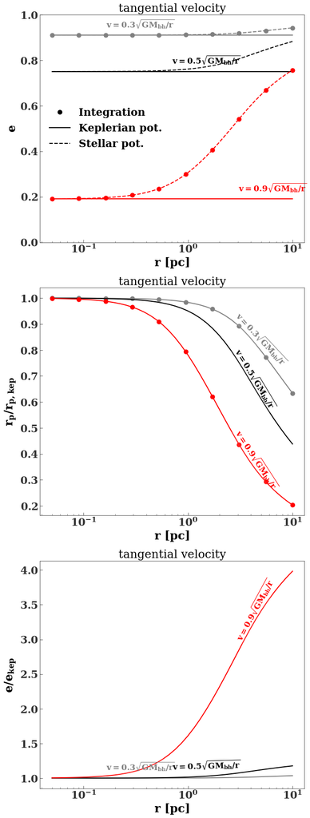

```python
from labelLine import labelLines

absc=np.geomspace(0.05, 10, 40)

ratio1=np.array([kep_ecc_compare(rr, 0.3, 0., pot_dp, pot_fun_args=(4.93e4, 3., 1.84, 0.1)) for rr in absc])
ratio2=np.array([kep_ecc_compare(rr, 0.5, 0., pot_dp, pot_fun_args=(4.93e4, 3., 1.84, 0.1)) for rr in absc])
ratio3=np.array([kep_ecc_compare(rr, 0.9, 0., pot_dp, pot_fun_args=(4.93e4, 3., 1.84, 0.1)) for rr in absc])
################################################

fig,axs=plt.subplots(nrows=3,  figsize=(10,30))


###############################################

ax=axs[0]
ax.set_xlabel('r [pc]')
ax.set_ylabel(r'$e$')
ax.set_ylim(0,1)
ax.plot([0.1, 0.1], [1.1, 1.1], marker='o', color='k', linestyle='None', label='Integration')
ax.plot([0.1, 0.2], [1.1, 1.1], '-', color='k',  label='Keplerian pot.')
ax.plot([0.1, 0.2], [1.1, 1.1], '--', color='k',  label='Stellar pot.')

################################################################################
ax.legend()

l1,=ax.semilogx(absc, ratio1[:,1], color='0.5', label=r'$v=0.3 \sqrt{G M_{bh}/r}$')
ax.semilogx(absc, ratio1[:,2], '--', color='0.5', label=r'$v=0.3 \sqrt{G M_{bh}/r}$')
ax.semilogx(np.geomspace(0.05, 10, 10), ck[:,1], marker='o', color='0.5', linestyle='None')

l2,=ax.semilogx(absc, ratio2[:,1], color='k', label=r'$v=0.5 \sqrt{G M_{bh}/r}$')
ax.semilogx(absc, ratio2[:,2], '--', color='k', label=r'$v=0.5 \sqrt{G M_{bh}/r}$')

l3,=ax.semilogx(absc, ratio3[:,1], color='r', label=r'$v=0.9 \sqrt{G M_{bh}/r}$')
ax.semilogx(absc, ratio3[:,2], '--', color='r', label=r'$v=0.9 \sqrt{G M_{bh}/r}$')
ax.semilogx(np.geomspace(0.05, 10, 10), ck2[:,1], marker='o', color='r', linestyle='None')
labelLines([l1, l2, l3], fontsize=17)
ax.set_title('tangential velocity')

#####################################################

ax=axs[1]
ax.set_xlabel('r [pc]')
ax.set_ylabel(r'$r_p/r_{p, kep}$')
l1,=ax.semilogx(absc, ratio1[:,-1], color='0.5', label=r'$v=0.3 \sqrt{G M_{bh}/r}$')
ax.semilogx(np.geomspace(0.05, 10, 10), ck[:,0], marker='o', color='0.5', linestyle='None')

l2,=ax.semilogx(absc, ratio2[:,-1], color='k', label=r'$v=0.5 \sqrt{G M_{bh}/r}$')
l3,=ax.semilogx(absc, ratio3[:,-1], color='r', label=r'$v=0.9 \sqrt{G M_{bh}/r}$')
ax.semilogx(np.geomspace(0.05, 10, 10), ck2[:,0], marker='o', color='r', linestyle='None')

ax.set_title('tangential velocity')


labelLines([l1, l2, l3], fontsize=17, xvals=[3, 3, 3])

######################################################################

ax=axs[2]
ax.set_xlabel('r [pc]')
ax.set_ylabel(r'$e/e_{kep}$')


l1,=ax.semilogx(absc, ratio1[:,0], color='0.5', label=r'$v=0.3 \sqrt{G M_{bh}/r}$')
l2,=ax.semilogx(absc, ratio2[:,0], 'k-', label=r'$v=0.5 \sqrt{G M_{bh}/r}$')
l3,=ax.semilogx(absc, ratio3[:,0], 'r-', label=r'$v=0.9 \sqrt{G M_{bh}/r}$')
ax.set_title('tangential velocity')
labelLines([l1, l2, l3], fontsize=17)
```

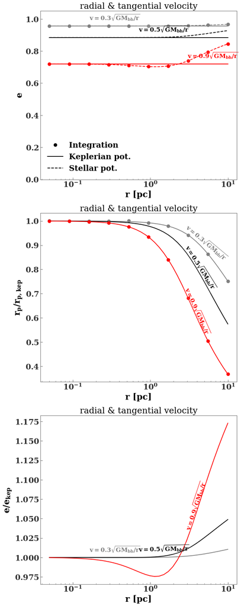

```python
from labelLine import labelLines

absc=np.geomspace(0.05, 10, 40)

ratio1=np.array([kep_ecc_compare(rr, 0.3, 1., pot_dp, pot_fun_args=(4.93e4, 3., 1.84, 0.1)) for rr in absc])
ratio2=np.array([kep_ecc_compare(rr, 0.5, 1., pot_dp, pot_fun_args=(4.93e4, 3., 1.84, 0.1)) for rr in absc])
ratio3=np.array([kep_ecc_compare(rr, 0.9, 1., pot_dp, pot_fun_args=(4.93e4, 3., 1.84, 0.1)) for rr in absc])
################################################

fig,axs=plt.subplots(nrows=3,  figsize=(10,30))


###############################################

ax=axs[0]
ax.set_xlabel('r [pc]')
ax.set_ylabel(r'$e$')
ax.set_ylim(0,1.05)
ax.plot([0.1, 0.1], [1.1, 1.1], marker='o', color='k', linestyle='None', label='Integration')
ax.plot([0.1, 0.2], [1.1, 1.1], '-', color='k',  label='Keplerian pot.')
ax.plot([0.1, 0.2], [1.1, 1.1], '--', color='k',  label='Stellar pot.')

################################################################################
ax.legend()

l1,=ax.semilogx(absc, ratio1[:,1], color='0.5', label=r'$v=0.3 \sqrt{G M_{bh}/r}$')
ax.semilogx(absc, ratio1[:,2], '--', color='0.5', label=r'$v=0.3 \sqrt{G M_{bh}/r}$')
ax.semilogx(np.geomspace(0.05, 10, 10), ckb[:,1], marker='o', color='0.5', linestyle='None')

l2,=ax.semilogx(absc, ratio2[:,1], color='k', label=r'$v=0.5 \sqrt{G M_{bh}/r}$')
ax.semilogx(absc, ratio2[:,2], '--', color='k', label=r'$v=0.5 \sqrt{G M_{bh}/r}$')

l3,=ax.semilogx(absc, ratio3[:,1], color='r', label=r'$v=0.9 \sqrt{G M_{bh}/r}$')
ax.semilogx(absc, ratio3[:,2], '--', color='r', label=r'$v=0.9 \sqrt{G M_{bh}/r}$')
ax.semilogx(np.geomspace(0.05, 10, 10), ck2b[:,1], marker='o', color='r', linestyle='None')
labelLines([l1, l2, l3], fontsize=17)
ax.set_title('radial & tangential velocity')

#####################################################

ax=axs[1]
ax.set_xlabel('r [pc]')
ax.set_ylabel(r'$r_p/r_{p, kep}$')
l1,=ax.semilogx(absc, ratio1[:,-1], color='0.5', label=r'$v=0.3 \sqrt{G M_{bh}/r}$')
ax.semilogx(np.geomspace(0.05, 10, 10), ckb[:,0], marker='o', color='0.5', linestyle='None')

l2,=ax.semilogx(absc, ratio2[:,-1], color='k', label=r'$v=0.5 \sqrt{G M_{bh}/r}$')
l3,=ax.semilogx(absc, ratio3[:,-1], color='r', label=r'$v=0.9 \sqrt{G M_{bh}/r}$')
ax.semilogx(np.geomspace(0.05, 10, 10), ck2b[:,0], marker='o', color='r', linestyle='None')

ax.set_title('radial & tangential velocity')


labelLines([l1, l2, l3], fontsize=17, xvals=[3, 3, 3])

######################################################################

ax=axs[2]
ax.set_xlabel('r [pc]')
ax.set_ylabel(r'$e/e_{kep}$')


l1,=ax.semilogx(absc, ratio1[:,0], color='0.5', label=r'$v=0.3 \sqrt{G M_{bh}/r}$')
l2,=ax.semilogx(absc, ratio2[:,0], 'k-', label=r'$v=0.5 \sqrt{G M_{bh}/r}$')
l3,=ax.semilogx(absc, ratio3[:,0], 'r-', label=r'$v=0.9 \sqrt{G M_{bh}/r}$')
ax.set_title('radial & tangential velocity')
labelLines([l1, l2, l3], fontsize=17)
```